# Étude de la production de pommes

Maurice Thomas & Thiret Juliette

30 octobre 2019

# Manipulation de la base de données

```
      vCap             vLab              vMat            qApples
 Min.   :  8951   Min.   :  79569   Min.   :  27781   Min.   : 0.00061
 1st Qu.: 50856   1st Qu.: 139379   1st Qu.:  81023   1st Qu.: 0.42699
 Median : 84115   Median : 175871   Median : 136292   Median : 1.37049
 Mean   :102576   Mean   : 237199   Mean   : 201250   Mean   : 3.06791
 3rd Qu.:123252   3rd Qu.: 259314   3rd Qu.: 224801   3rd Qu.: 3.25943
 Max.   :452146   Max.   :1682201   Max.   :1523776   Max.   :37.98153
   qOtherOut            qOut               pCap             pLab
 Min.   :0.01498   Min.   :   95391   Min.   :0.1678   Min.   :0.4928
 1st Qu.:0.56417   1st Qu.:  998789   1st Qu.:0.7722   1st Qu.:0.8633
 Median :1.07315   Median : 1773989   Median :1.1073   Median :0.9607
 Mean   :1.50075   Mean   : 2649825   Mean   :1.3032   Mean   :1.0077
 3rd Qu.:1.92083   3rd Qu.: 3152400   3rd Qu.:1.6194   3rd Qu.:1.1864
 Max.   :5.96256   Max.   :24210264   Max.   :4.4846   Max.   :1.7221
      pMat             pOut             adv
 Min.   : 2.699   Min.   :0.4572   Min.   :0.0000
 1st Qu.: 4.870   1st Qu.:0.6634   1st Qu.:0.0000
 Median : 6.252   Median :0.8258   Median :1.0000
 Mean   : 6.774   Mean   :1.0087   Mean   :0.5214
 3rd Qu.: 8.372   3rd Qu.:1.1129   3rd Qu.:1.0000
 Max.   :15.706   Max.   :2.9430   Max.   :1.0000
```

```
Classes 'data.table' and 'data.frame':  140 obs. of  11 variables:
 $ vCap     : int  219183 130572 81301 34007 38702 122400 89061 92134 65779 94047 ...
 $ vLab     : int  323991 187956 134147 105794 83717 523842 168140 204859 180598 142240 ...
 $ vMat     : int  303155 262017 90592 59833 104159 577468 343768 126547 190622 82357 ...
 $ qApples  : num  1.392 0.864 3.317 0.438 1.831 ...
 $ qOtherOut: num  0.977 1.072 0.405 0.436 0.015 ...
 $ qOut     : num  1374064 1122979 2158518 507389 1070816 ...
 $ pCap     : num  2.608 3.292 2.194 1.602 0.866 ...
 $ pLab     : num  0.9 0.753 0.956 1.268 0.938 ...
 $ pMat     : num  8.89 6.42 3.74 3.17 7.22 ...
 $ pOut     : num  0.66 0.716 0.937 0.597 0.825 ...
 $ adv      : int  0 0 1 1 1 1 1 0 0 0 ...
 - attr(*, ".internal.selfref")=<externalptr>
```

Toutes les variables sont bien codées.

```r
data$adv<-as.factor(data$adv)
```

**Création de variables : les quantités de facteurs**

```r
data$qCap<-(data$vCap/data$pCap)
data$qMat<-(data$vMat/data$pMat)
data$qLab<-(data$vLab/data$pLab)
```

**Calcul des productions moyennes de chaque input**

Vérification du cout total

```r
#cout total
data[,cost:=vCap+vLab+vMat]
all.equal(data$cost, with( data, pCap * qCap + pLab * qLab + pMat * qMat ))
```

```
[1] TRUE
```

```r
#cout variable
data[,vCost:=vLab+vMat]
```

# Statistiques descriptives

On remarque que beaucoup de variables sont corrélées entre elles. Mais ces corrélations semblent logiques

Part des couts dans le cout total

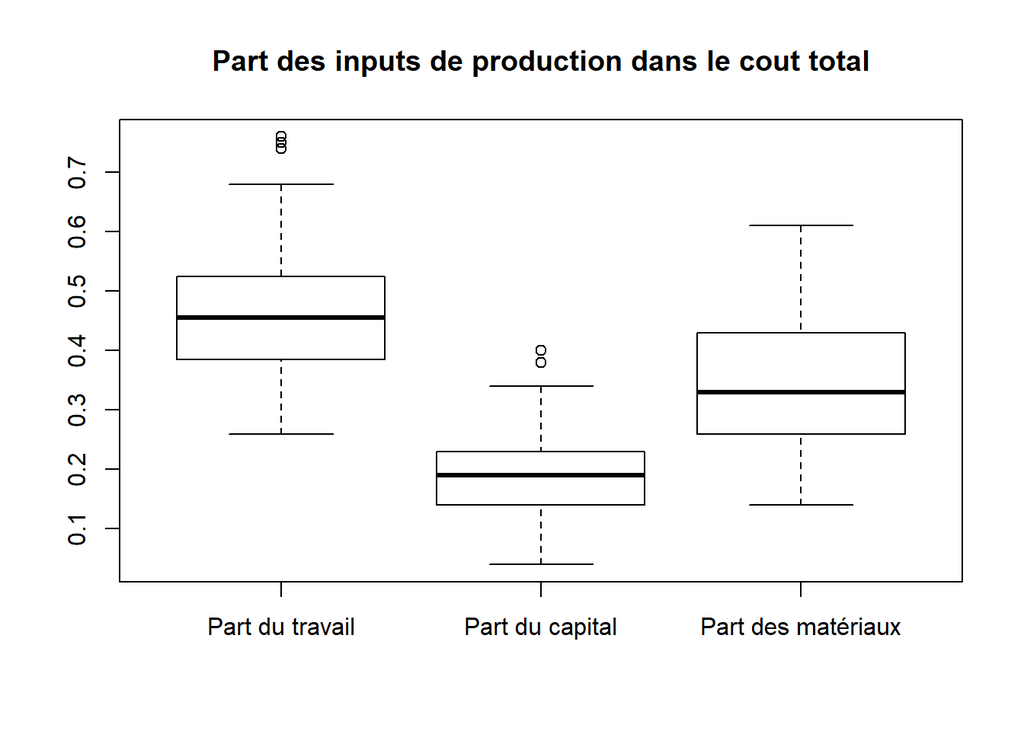

Part du travail est celle qui a une plus grande part dans la production, suivi des matériaux et du capital.

```
`geom_smooth()` using method = 'loess' and formula 'y ~ x'
```

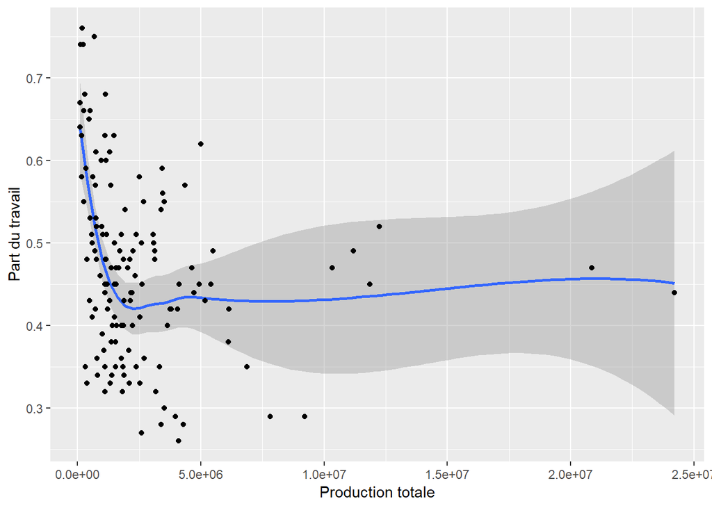

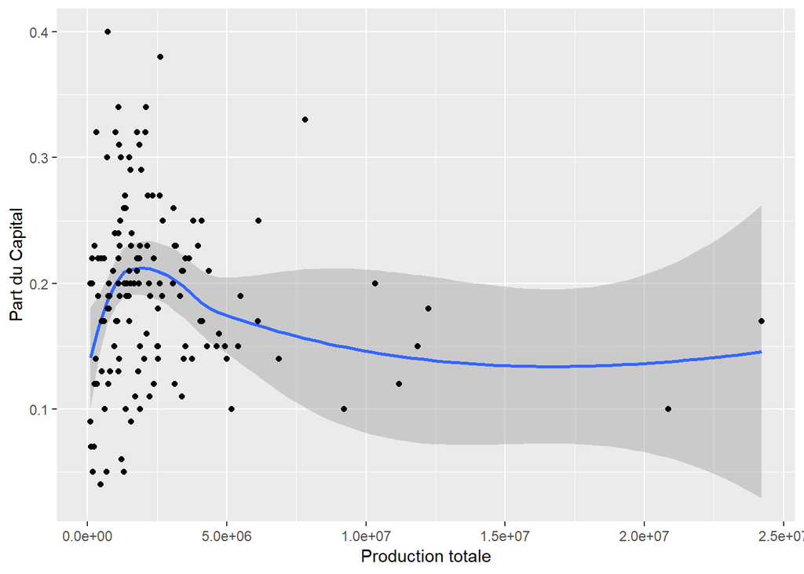

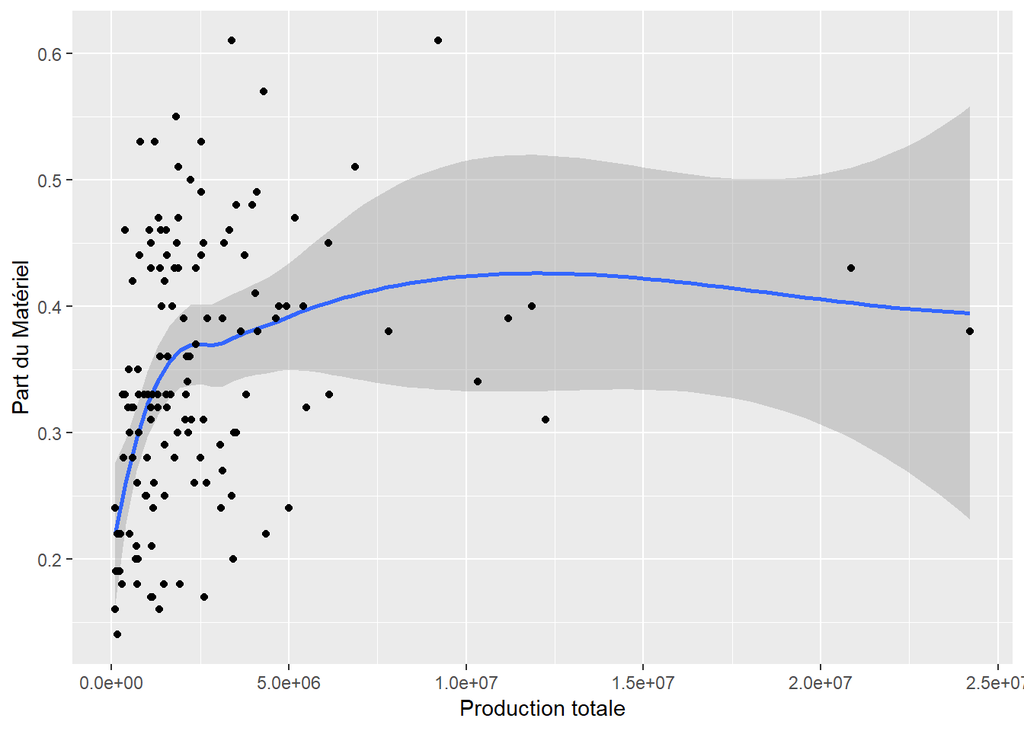

On remarque que les intervalles de confiance sont très grand, ce qui signifie que pour quelques outliers (gros producteurs) biaisent la tendance général. Nous proposons donc de créer une variable qualitative qui prend soit la modalité petit_producteur et gros_producteur. Cela permettra d’avoir une analyse plus fine des parts des inputs dans la production.

*Création de la variable Taille_producteur*

**Petit producteur vs gros producteur**

```
`geom_smooth()` using method = 'loess' and formula 'y ~ x'
```

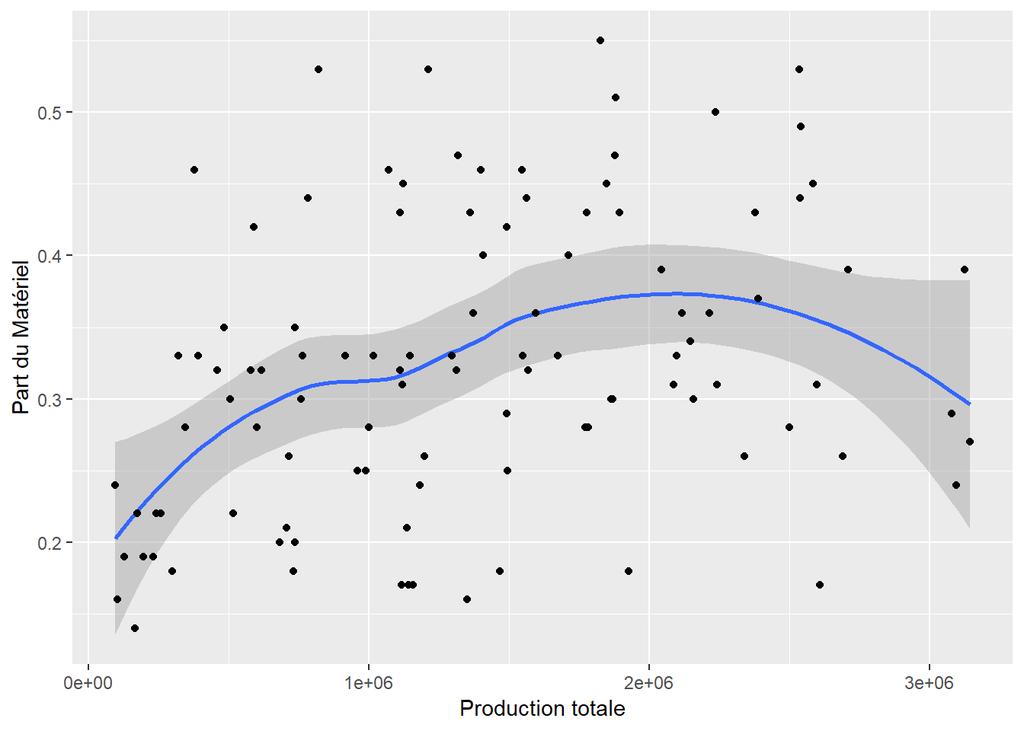

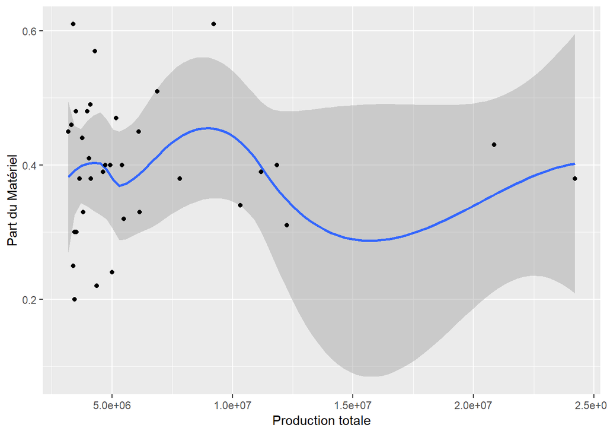

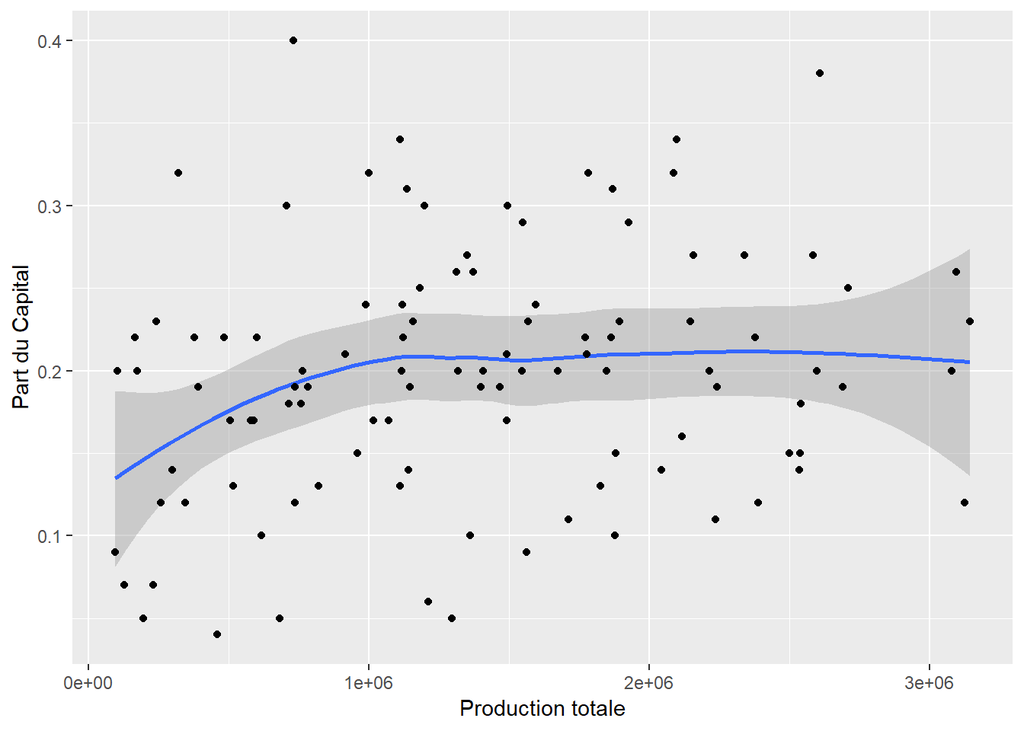

[figure not shown]

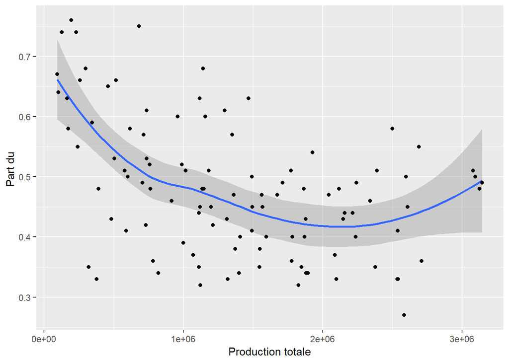

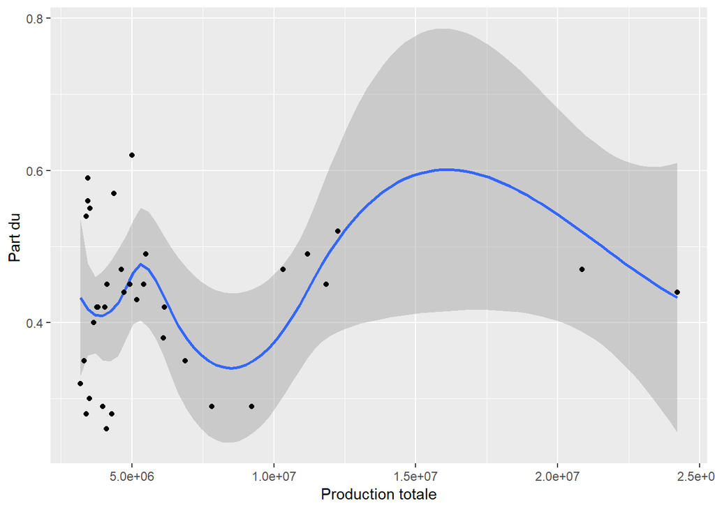

**Etape 1: Histogrammes**

Représentez les histogrammes des productivités moyennes des facteurs de production de Cap, Lab et Mat.

On considère donc les 3ieres colonnes

**Histogrammes des productivités moyennes**

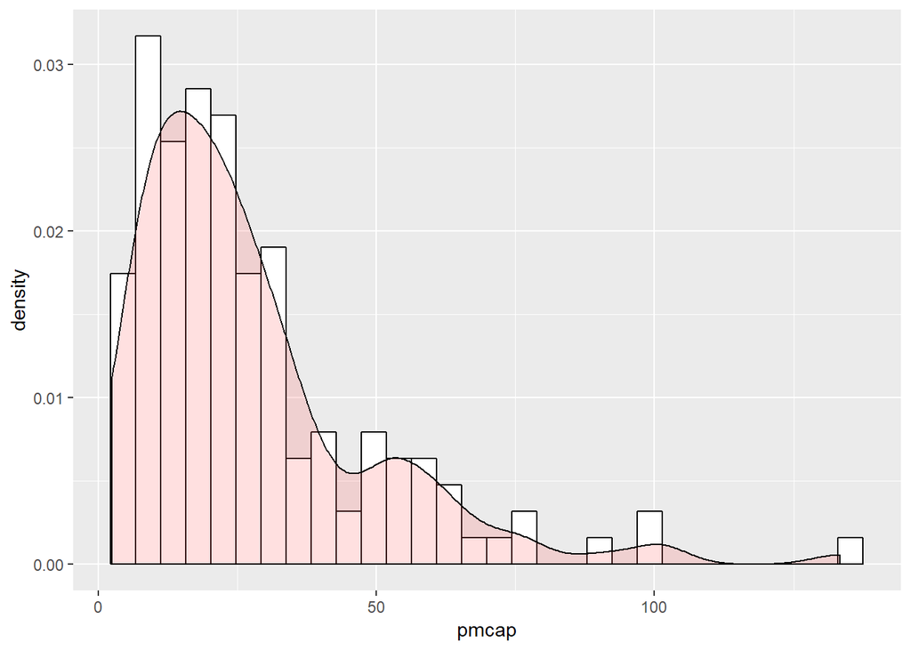

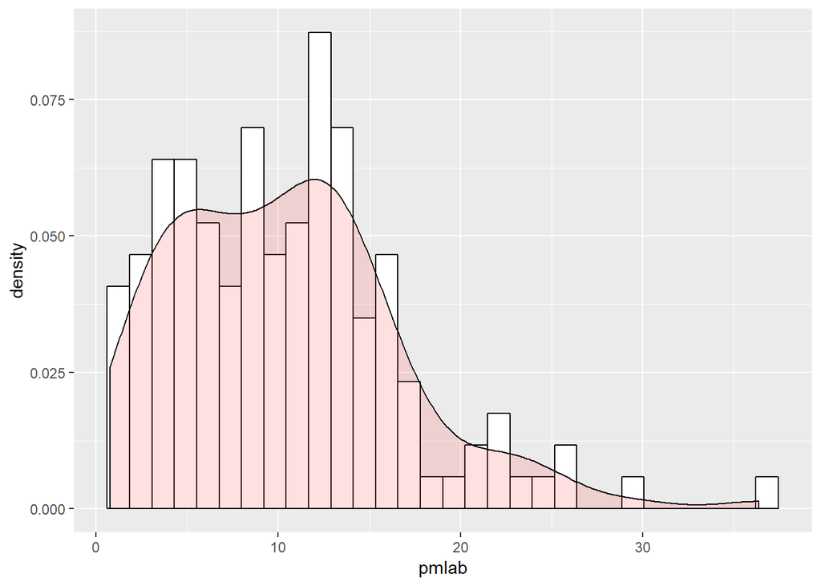

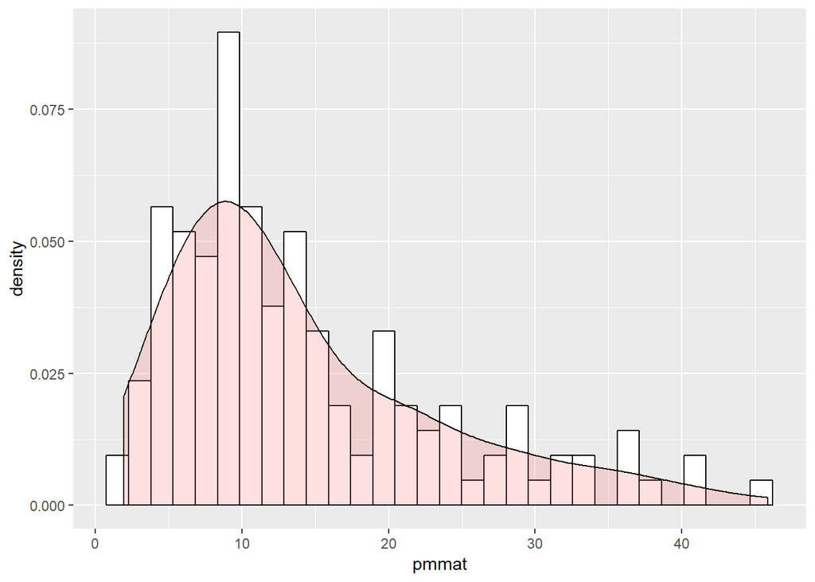

**Etape 2** : Etude des corrélations.

Etudiez les corrélations entre les quantités des 3 facteurs de production utilisés dans ce secteur

Donnez la matrice des corrélations, et représentez graphiquement le nuage de point correspondant aux différents croisements des productivités moyennes prises deux à deux. Représentez aussi les 3 séries de productivité moyenne par rapport à l’output total qOut. ###Matrice des corrélations

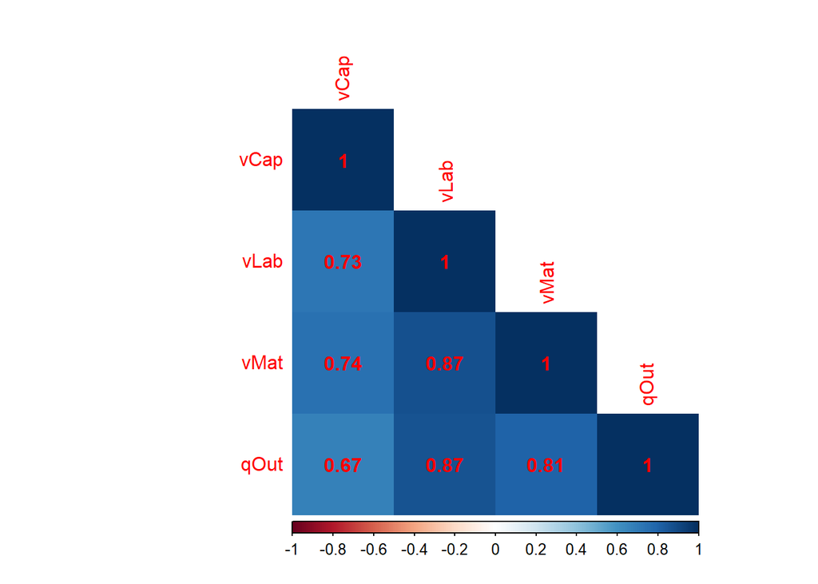

### Nuage de point

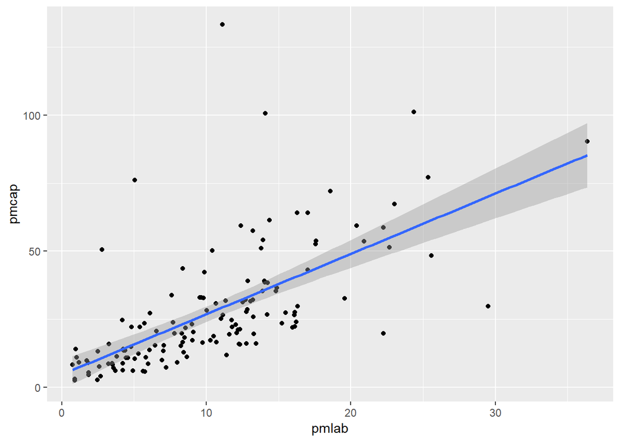

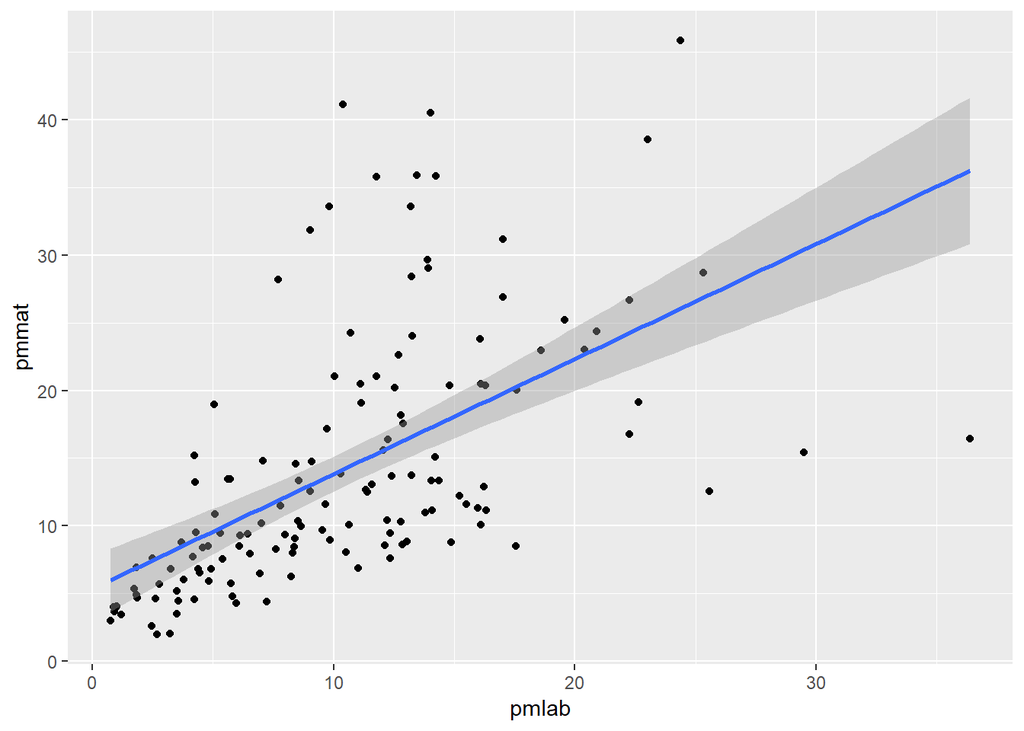

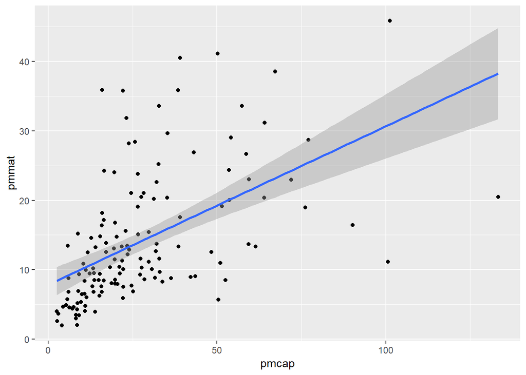

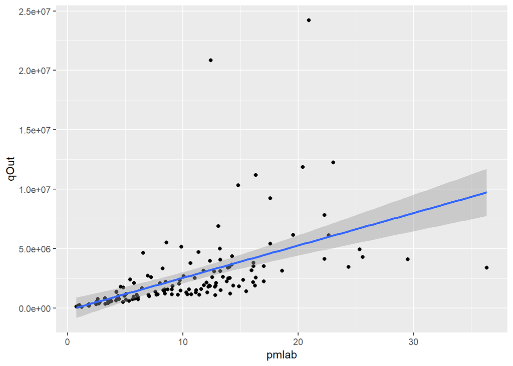

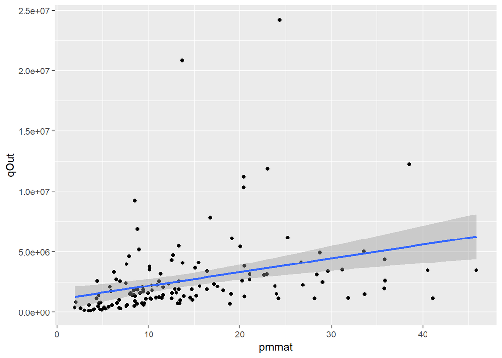

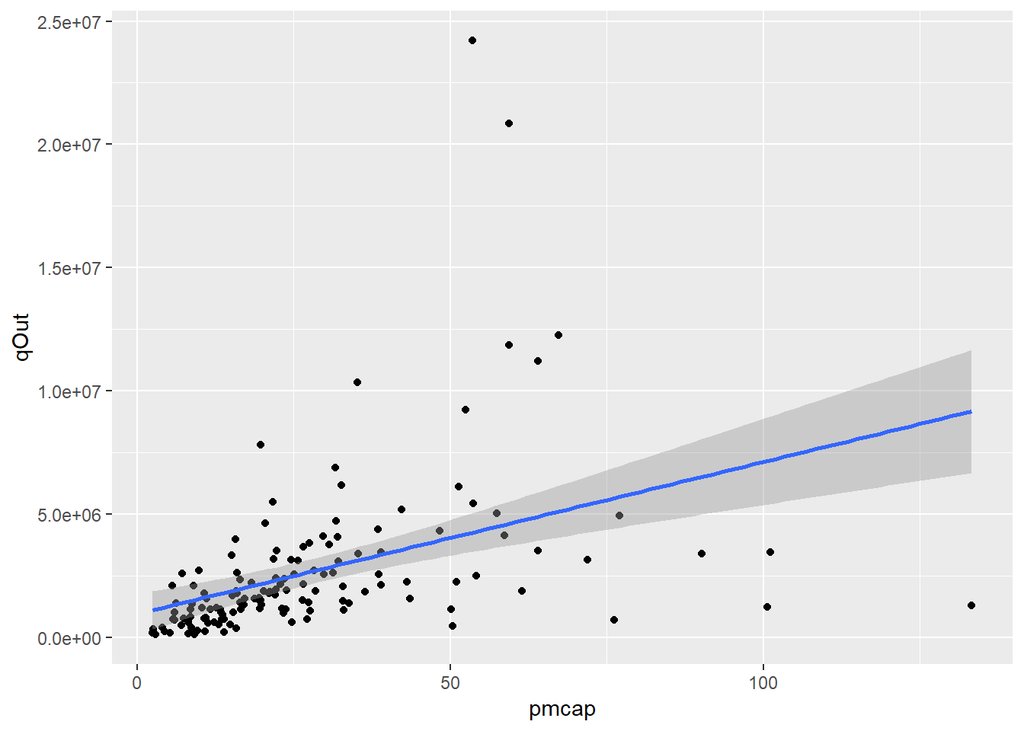

**Etape 3** : Calcul des indices de Pasches, Laspeyres et Fisher

Indice de valeur = indice de prix × indice de volume indice de volume = indice de valeur / indice de prix

```r
data[,XP:=(vCap+vLab+vMat) / (mean(qCap)*pCap + mean(qLab)*pLab + mean(qMat)*pMat)]
data[,XL:=(qCap*mean(pCap) + qLab*mean(pLab) + qMat*mean(pMat)) /
       (mean(qCap)*mean(pCap) + mean(qLab)*mean(pLab) + mean(qMat)*mean(pMat))]
data[,XF:=sqrt(XP*XL)]
```

**Etape 4** : Calcul d’un indice de productivité globale des facteurs

```r
data[,PGF:= qOut/XF]
```

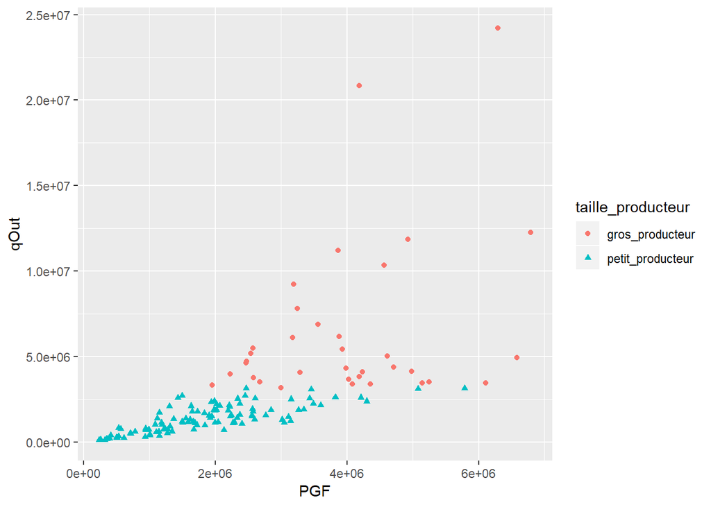

**Etape 5** : Productivité globale et relations avec les quantités de facteurs